# Downsizing and surviving employees' engagement and strain: The role of job resources and job demands

Converted from PDF `Dlouhy-SurvivorEngagementStrain-2021-HRM.pdf` · 20 pages · anchors: page `#pN`, block `#pN-bK`

Page 1

#### **O R I G I N A L A R T I C L E**

## **Downsizing and surviving employees' engagement and strain: The role of job resources and job demands**

### **Katja Dlouhy | Anne Casper**

University of Mannheim, Mannheim, Germany

**Correspondence** Katja Dlouhy, University of Mannheim, Mannheim, Germany. Email: katja.dlouhy@bwl.uni-mannheim.de

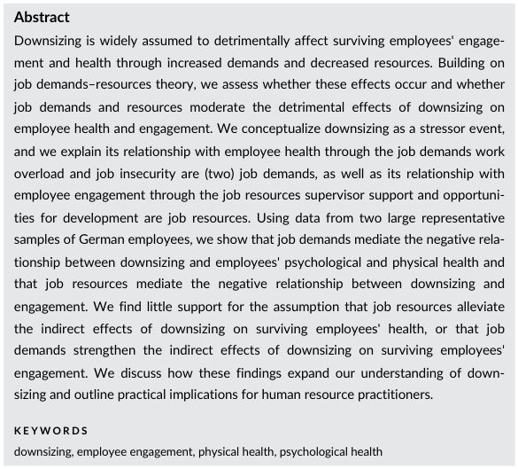

NOTE: figure/graphic rendered as an image from the PDF; its content is not machine-readable text. Caption (if any) follows as the next block.

**text found inside the figure**

**Abstract**

Downsizing is widely assumed to detrimentally affect surviving employees' engage-

ment and health through increased demands and decreased resources. Building on

job demands–resources theory, we assess whether these effects occur and whether

job demands and resources moderate the detrimental effects of downsizing on

employee health and engagement. We conceptualize downsizing as a stressor event,

employee engagement through the job resources supervisor support and opportuni-

ties for development are job resources. Using data from two large representative

samples of German employees, we show that job demands mediate the negative rela-

tionship between downsizing and employees' psychological and physical health and

that job resources mediate the negative relationship between downsizing and

engagement. We find little support for the assumption that job resources alleviate

the indirect effects of downsizing on surviving employees' health, or that job

demands strengthen the indirect effects of downsizing on surviving employees'

engagement. We discuss how these findings expand our understanding of down-

sizing and outline practical implications for human resource practitioners.

**K E Y W O R D S**

downsizing, employee engagement, physical health, psychological health

### **1** | **INTRODUCTION**

Workforce downsizing is one of the most significant topics in the area

of human resource management. Organizations usually justify down-

sizing with expectations of higher organizational performance

(Datta & Basuil, 2015); however, these expectations often are not met

due to negative reactions of employees who remain in the organiza-

tion (Datta, Guthrie, Basuil, & Pandey, 2010). Research on reactions of

these employees, who are termed “downsizing survivors,” has shown

that downsizing negatively affects their attitudes (Allen, Freeman,

Russell, Reizenstein, & Rentz, 2001; Luthans & Sommer, 1999;

Travaglione & Cross, 2006) and health (Grunberg, Moore, &

Greenberg, 2001; Kivimäki et al., 2001; Snorradóttir, Vilhjálmsson,

Rafnsdóttir, & Tómasson, 2013).

Previous studies that focused on surviving employees mostly

examined downsizing under the tenets of various social exchange the-

ories (e.g., Arshad & Sparrow, 2010; Iverson & Zatzick, 2011; Kalimo,

Taris, & Schaufeli, 2003) and justice theories (e.g., Brockner et al.,

2004; Brockner, Grover, O'Malley, Reed, & Glynn, 1993; Spreitzer &

Mishra, 2002). Some studies have taken a stress perspective toward

downsizing, showing that this organizational event increases surviving

employees' job demands and negatively affects their health (Devine,

DOI: 10.1002/hrm.22032

This is an open access article under the terms of the Creative Commons Attribution License, which permits use, distribution and reproduction in any medium, provided the original work is properly cited. © 2020 The Authors. *Human Resource Management* published by Wiley Periodicals LLC.

*Hum Resour Manage.* 2021;60:435–454. wileyonlinelibrary.com/journal/hrm **435**

Page 2

Reay, Stainton, & Collins-Nakai, 2003; Harney, Fu, & Freeney, 2018;

Moore, Grunberg, & Greenberg, 2004). However, motivational reac-

tions of surviving employees have not received attention in the litera-

ture that conceptualizes downsizing as a stressor. Furthermore, it is

typically assumed that changes in surviving employees' motivation

and health after downsizing are due to changes in job demands and

job resources, but in most cases, these relationships have not been

explicitly tested. Thus, little consideration has been given to mediators

of the relationship between downsizing and survivors' health

(Grunberg et al., 2001; Harney et al., 2018; Kivimäki et al., 2001), and

mediators of the relationship between downsizing and survivors'

engagement have been completely disregarded. Furthermore, an

overall lack of focus on job resources remains, despite the fact that

their importance in the downsizing process has been emphasized

(Harney et al., 2018; Mishra & Spreitzer, 1998) and that they might

buffer adverse effects of downsizing on strain. Moreover, few studies

have tested the effect of a downsizing event in representative sam-

ples that include survivors and a comparison group.

We report two studies that address these gaps in the literature,

building on job demands–resources (JD-R) theory (Demerouti, Bakker,

Nachreiner, & Schaufeli, 2001). Downsizing is an organizational event

that may lead to changes in the working conditions of surviving

employees (Sonnentag & Frese, 2003). JD-R theory aids in under-

standing the mechanisms through which this organizational event

leads to changes in surviving employees' engagement and strain

through changes in job demands and job resources. Applying this the-

oretical perspective allows for new insights on the effect of down-

sizing on surviving employees' engagement, as other studies that have

applied a stress perspective to downsizing only focused on

employees' strain reactions (e.g., Devine et al., 2003; Harney et al.,

2018; Moore et al., 2004). Furthermore, JD-R theory can aid in under-

standing how the effects of downsizing on strain through increased

job demands might be diminished, as we expect the effects to be less

pronounced when downsizing survivors have more job resources. We

focus on how downsizing affects the job resources of supervisor sup-

port and opportunities for development, which we consider as media-

tors of the negative relationship between downsizing and

engagement, and on how downsizing affects the job demands of work

overload and job insecurity, which we consider as mediators of the

negative relationship between downsizing and health. Furthermore,

we position job resources as moderators of the relationship between

downsizing and health that is mediated by job demands, and job

demands as moderators of the relationship between downsizing and

engagement that is mediated by job resources.

We open with an account of the pathways through which down-

sizing may affect downsizing survivors' engagement and health. We

then test our proposed moderated-mediation model, which is

depicted in Figure 1, in two studies. In Study 1, we use cross-sectional

data of 3,865 employees, and we replicate and extend the findings in

Study 2 with data from another sample of 3,290 employees over two

measurement points.

Our research makes three main contributions that address several

gaps in past research. First, we develop a set of hypotheses regarding

mediators of the relationships between downsizing and both

employee engagement and strain, which are important determinants

of organizational performance (Bakker & Demerouti, 2017). Datta

et al. (2010) identified a need to study mediating mechanisms that link

downsizing to employee outcomes. Our examination of mediating

processes will help human resource researchers and practitioners to

understand the reasons why downsizing may have negative conse-

quences for surviving employees' engagement and health, and thus

open up avenues to counter these consequences.

Second, by examining how downsizing affects supervisor support

and opportunities for development, we correct the imbalance in the

extant literature in which the emphasis is on demands rather than

resources. This is important because job resources enable employees

to achieve work goals and stimulate personal growth (Bakker &

Demerouti, 2017). Furthermore, by positioning these resources as

moderators of the indirect relationships between downsizing and

employee strain, we answer the call to examine boundary conditions

of downsizing effects (Datta et al., 2010). Addressing the question of

when adverse downsizing consequences might be less pronounced is

important for organizations that want to avoid employee strain after

downsizing.

Third, we use two samples that cover a broad range of occupa-

tions and organizations across the German economy and that include

a comparison group that did not experience downsizing. We also test

the actual effect of a downsizing event by controlling for previous

levels of job demands, job resources, engagement, and strain in Study

2. This, along with our large representative samples, strengthens infer-

ence for our tests beyond that of previous studies. Thus, our studies

make a significant contribution to the evidence base on negative

employee reactions that may counteract organizations' aim of higher

profitability (Datta & Basuil, 2015).

**2** | **CONCEPTUAL BACKGROUND AND HYPOTHESES**

### **2.1** | **Downsizing consequences**

Workforce downsizing is an organizational change event that entails

personnel reductions in the organizational context (Cascio, 1993). We

focus on downsizing consequences for those employees who remain

in the organization (i.e., downsizing survivors). Downsizing is regarded

as a stressor by surviving employees (Devine et al., 2003; Sonnentag &

Frese, 2003) and has been positioned in the context of recessions in

previous studies (Snorradóttir et al., 2013; Wood, Michaelides, &

Ogbonnaya, 2020). However, it is not necessarily a consequence of

decreased demand for organizations' products or services, as “proac-

tive” downsizing may also occur during periods of healthy demand

with the intention of enhancing long-term competitiveness (Datta &

Basuil, 2015).

Downsizing is typically associated with a decrease in employee

health (Quinlan & Bohle, 2009). Several studies have shown that

downsizing negatively relates to surviving employees' psychological

**436** DLOUHY AND CASPER

Page 3

and physical health (Andreeva, Hanson, Westerlund, Theorell, &

Brenner, 2015; Dragano, Verde, & Siegrist, 2005; Grunberg et al.,

2001; Kalimo et al., 2003; Kivimäki et al., 2001; Snorradóttir et al.,

2013), whereas only few studies did not find such an effect (Østhus,

2007; Østhus, 2012). All these studies assessed employees' health

with self-report measures; only one study of U.S. workers in a single

company showed that severity of downsizing is related to objective

measures of hypertension and diabetes (Modrek & Cullen, 2013). As

the use of self-reported health measures can lead to bias when study-

ing the effect of downsizing on physical health, more studies using

objective measures of health are warranted.

There is some evidence on job demands that might mediate the

relationship between downsizing and surviving employees' health.

Studies within single organizations (Amabile & Conti, 1999;

Armstrong-Stassen, 2005; Snorradóttir et al., 2013; Virick, Lilly, &

Casper, 2007), as well as studies that used representative samples of

employees from Norway (Østhus, 2007) and Ireland (Harney et al.,

2018), show that downsizing is related to higher quantitative work

demands. Harney et al. (2018) even find that work intensity mediates

the relationship between downsizing and employee exhaustion in a

cross-sectional study. Downsizing survivors also report higher job

insecurity (Allen et al., 2001; Armstrong-Stassen, 2005; Maertz, Wiley,

LeRouge, & Campion, 2010; Moore et al., 2004; Østhus, 2007). Two

studies within single organizations even find that job insecurity medi-

ates the relationship between downsizing and self-reported psycho-

logical and physical health among downsizing survivors (Grunberg

et al., 2001; Kivimäki et al., 2001). Several studies outside the down-

sizing literature focused on job resources that buffer the relationship

between job demands and employee strain (Bakker, Demerouti, &

Euwema, 2005; Xanthopoulou et al., 2007), but only Harney et al.

(2018) show that the job resource consultation mitigates the adverse

effect of increased work intensity on employee exhaustion after

downsizing.

Evidence on important job resources that might decrease after

downsizing, like managerial support (Foster, Hassard, Morris, &

Wolfram Cox, 2019) or training and development opportunities, is

scarce and inconclusive. Two studies that assessed survivor attitudes

over the downsizing period showed no significant decrease in supervi-

sor support (Amabile & Conti, 1999; Luthans & Sommer, 1999). Allen

et al. (2001) found that satisfaction with top management increases in

the downsizing process, whereas Armstrong-Stassen, Wagar, and

Cattaneo (2004) found a decrease of supervisor support. All these

studies were conducted within single organizations; only Ferrie,

Westerlund, Oxenstierna, and Theorell (2007) used a representative

sample of Swedish employees to show that downsizing negatively

affects a composite measure of supervisor and co-worker support.

We did not find any empirical evidence regarding whether career

development or training opportunities change for downsizing

survivors.

Extant literature also provides little evidence of downsizing con-

sequences for employee attitudes. Luthans and Sommer (1999) found

decreased affective commitment and job satisfaction in employees of

an organization undergoing downsizing, and Travaglione and Cross

(2006) confirmed these findings. Allen et al. (2001) show that organi-

zational commitment and job involvement of managers decreased

after downsizing. To date, there is a lack of evidence of the effect of

downsizing on employee engagement, motivation, or work effort. Sev-

eral studies used samples of downsizing survivors but did not include

downsizing as study variable (e.g., Arshad & Sparrow, 2010; Brockner

et al., 1993; Brockner, Grover, Reed, & Dewitt, 1992; Cotter & Fouad,

2013). In the following, we take this work forward by focusing on vari-

ous pathways that shape surviving employees' engagement and strain

after a downsizing event.

### **2.2** | **Theoretical framework**

We expect downsizing to result in increased strain and lowered

engagement in surviving employees through changes in their working

conditions that entail increased job demands and reduced job

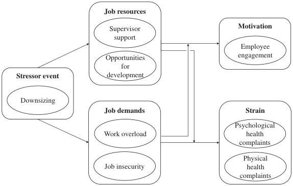

NOTE: figure/graphic rendered as an image from the PDF; its content is not machine-readable text. Caption (if any) follows as the next block.

**text found inside the figure**

Work overload

Supervisor

support

**Stressor event**

**Job demands** Downsizing

**Job resources**

Opportunities

for development

Physical

health complaints

**Strain**

Psychological

health complaints

**Motivation**

Employee engagement

Job insecurity

**FIGURE 1** Hypothesized model

DLOUHY AND CASPER **437**

Page 4

resources. We base our reasoning on the job demands–resources

model (Demerouti et al., 2001), which posits that a state of high strain

and low engagement is caused by two processes. First, being exposed

to high job demands causes strain in employees via a health impair-

ment process. Specifically, high job demands cause a process of

energy depletion because employees need to invest energy in order

to deal with the demands they face, which in turn will eventually

result in decreased health of the employees (Demerouti et al., 2001).

Second, a lack of job resources in one's work environment causes dis-

engagement. Specifically, when employees lack resources, their

engagement in and motivation for work will suffer because they can-

not reach their work goals (Demerouti et al., 2001). According to the

JD-R model, job resources buffer the association between job

demands and strain, while job demands moderate the relationship

between job resources and engagement such that a combination of

high job demands and high job resources is associated with increased

engagement (Bakker & Demerouti, 2017).

We argue that downsizing results in an increase in job demands,

which will in turn increase strain levels for the surviving employees.

Job demands refer to all physical, social, and organizational aspects of

the job that require effort on the part of the employee (Demerouti

et al., 2001). Examples of job demands include a high workload, social

conflicts, and role ambiguity (Sonnentag & Frese, 2003). Job strain

refers to negative reactions that employees display in response to job

demands (Spector, Chen, & O'Connell, 2000) and may refer to physi-

cal, psychological, and behavioral strains. In the present study, we

examine the job demands work overload and job insecurity, as these

are two important direct consequences of corporate restructuring

(Foster et al., 2019), and because they are known to be particularly

relevant for employee strain (Bowling, Alarcon, Bragg, & Hartman,

2015; Shoss, 2017).

Additionally, we argue that downsizing is followed by a decrease

in employees' job resources, which in turn will result in lower levels of

engagement for the surviving employees. Job resources refer to

aspects of one's job that reduce the physiological and psychological

costs of job demands, help employees achieve their work goals, or

stimulate the personal development of the employee (Bakker &

Demerouti, 2007). Examples of job resources include social support,

autonomy in how tasks are carried out, performance feedback, and

opportunities for career development (Bakker & Demerouti, 2007).

The JD-R model posits that job resources lead to employee engage-

ment via a motivational process (Demerouti et al., 2001). Employee

engagement is defined as a “positive, fulfilling work-related state of

mind” (Schaufeli & Bakker, 2004, p. 295) and involves feeling ener-

getic, enthusiastic, and absorbed at work. In the present study, we

focus on supervisor support and opportunities for development as

particularly relevant job resources after a downsizing event

(Amundson, Borgen, Jordan, & Erlebach, 2004).

While downsizing is likely followed by a decrease in social sup-

port and opportunities for development, we argue that if employees

receive or keep these important resources after a downsizing event,

they may attenuate the negative consequences that increased

demands have on their well-being. The JD-R model states that job

resources moderate the relationship between job demands and

employee strain (Demerouti et al., 2001), because they help

employees to better cope with job demands (Bakker &

Demerouti, 2007). Furthermore, as job resources are especially

important for employee engagement when job demands are high

(Bakker & Demerouti, 2017), downsizing will be associated with

even lower engagement of surviving employees when job

demands are high.

**2.3** | **Downsizing, job demands, and employee strain**

Based on this theoretical background, we argue that downsizing is

associated with an increase in work overload and job insecurity, which

in turn relates to increases in employee strain; that is, decreases in

psychological and physical health. Work overload is a job demand that

involves having to do a large amount of work in too little time

(Spector & Jex, 1998). Downsizing survivors often have to complete

the tasks of downsizing victims in addition to their own (Boyd,

Tuckey, & Winefield, 2014; Cascio, 1993; Spreitzer & Mishra, 2002),

and the additional tasks are seldom equally distributed and match sur-

viving employees' competencies (Mishra & Spreitzer, 1998). Thus,

downsizing will be related to increases in work overload for the

remaining employees. According to the JD-R model, being exposed to

work overload triggers a health impairment process that results in

employee strain (Demerouti et al., 2001). When facing work overload,

employees increase efforts and mobilize sympathetic activation

(Demerouti et al., 2001) in order to manage their high levels of work-

load. These increases in activation and effort, in turn, are associated

with physiological costs, which result in a state of energy depletion

and a decline in psychological and physical health (Demerouti et al.,

2001). This may manifest in increased depressive symptoms and less

physical strength (Bowling et al., 2015; Nixon, Mazzola, Bauer,

Krueger, & Spector, 2011). Moreover, work overload may impair

employees' recovery from work, which helps employees maintain

health and well-being (Sonnentag, Venz, & Casper, 2017). We there-

fore hypothesize the following:

**Hypothesis 1:** *Downsizing negatively relates to employees*'

*(a) psychological health and (b) physical health through work*

*overload*.

Job insecurity is a job demand (Cheng & Chan, 2008) that is

defined as a perceived threat to the continuity and stability of

employment (Shoss, 2017). It can be triggered by downsizing, which is

seen as a warning sign that jobs in an organization are not safe

(Amundson et al., 2004; Maertz et al., 2010; Roskies & Louis-Guerin,

1990; Sverke, Hellgren, & Näswall, 2002). Due to its threatening

nature, job insecurity is associated with anxiety and worry (Shoss,

2017), which are indicators of increased activation levels that may

cause strain reactions (Meurs & Perrewé, 2011). Supporting this rea-

soning, previous studies provide evidence that job insecurity is related

**438** DLOUHY AND CASPER

Page 5

to psychological and physical strain (Cheng & Chan, 2008; De Witte,

Pienaar, & De Cuyper, 2016; Vander Elst, Notelaers, & Skogstad,

2018). For example, individuals who are afraid to lose their job might

show higher levels of presenteeism, which can have severe conse-

quences for their physical health (Miraglia & Johns, 2016). We

hypothesize:

**Hypothesis 2:** *Downsizing negatively relates to employees*' *(a) psycho-*

*logical health and (b) physical health through job insecurity*.

**2.4** | **Downsizing, job resources, and employee engagement**

We further propose that downsizing is related to a decrease in super-

visor support and opportunities for development for the remaining

employees, which in turn is related to a decrease in employee engage-

ment. Supervisor support refers to helping behaviors toward

employees and includes emotional and task-related behaviors

(Viswesvaran, Sanchez, & Fisher, 1999). Following downsizing, man-

agers report an increase of demands that they are unable to fulfill,

such as having to manage more employees than before or take over

new functions (Cameron, Freeman, & Mishra, 2011). Qualitative

research shows that when downsizing becomes emotionally burden-

some, downsizing agents, who are often supervisors, react by cogni-

tively, emotionally, and physically distancing themselves from their

roles (Clair & Dufresne, 2004). Thus, supervisors might not be able to

provide sufficient support to employees after downsizing. Decreases

in supervisor support, in turn, may impair employees' engagement.

Supervisor support satisfies important needs (Bakker & Demerouti,

2007) and motivates employees. In line with this reasoning, meta-

analytic evidence links supportive leadership to increased employee

engagement (Christian, Garza, & Slaughter, 2011). Based on the

above, we hypothesize the following:

**Hypothesis 3:** *Downsizing negatively relates to employees*' *engagement*

*through supervisor support*.

Opportunities for development can be defined as a job resource

that allows employees to develop their personal skills and engage in

workplace learning (Molino, Ghislieri, & Cortese, 2013). Most work-

place learning is informal (Molino et al., 2013), and may be impaired

after a downsizing event. For example, when supervisors and col-

leagues feel overwhelmed with increased and unfamiliar duties

(Cameron et al., 2011), they may be less able to provide learning

opportunities. Reduced learning and career advancement prospects

are perceived negatively by employees (Bozionelos, 2001), and a

decrease in opportunities for development will be associated with a

decrease in employee engagement (Bakker & Demerouti, 2007). Thus,

we hypothesize the following:

**Hypothesis 4:** *Downsizing negatively relates to employees*' *engagement*

*through opportunities for development*.

### **2.5** | **The moderating role of job resources**

Following the rationale of JD-R theory, we propose that the job

resources supervisor support and opportunities for development will

attenuate the relationships between downsizing and employee strain.

Social support moderates the relationship between job demands and

strain, such that those with more support will experience fewer health

complaints in response to high job demands (Van Veldhoven et al.,

2020). Specifically, receiving help from one's supervisor is important

during times of organizational change (Neves & Caetano, 2006) and

may help employees cope with increased demands. A supportive

supervisor may help employees by providing help or advice regarding

how to manage an increased workload or new and unfamiliar

demands (Mathieu, Eschleman, & Cheng, 2019) after downsizing.

Thus, we hypothesize the following:

**Hypothesis 5:** *Supervisor support moderates the relationships between*

*downsizing and (a) psychological health and (b) physical health*

*through work overload, such that the indirect relationships are*

*weaker for employees who have more (vs. less) supervisor support*.

Similarly, we expect that social support moderates the indirect

relationship between downsizing and employee strain via job insecu-

rity. Receiving support from one's supervisor after a downsizing event

makes employees feel more comfortable and is associated with more

trust in the organization and perceptions that the organization is reli-

able (Amundson et al., 2004). Thus, when employees receive more

supervisor support, the negative consequences of job insecurity might

be less pronounced, for example because a supportive supervisor will

prevent behavior such as presenteeism that affects employee health

(Miraglia & Johns, 2016).

**Hypothesis 6:** *Supervisor support moderates the relationships between*

*downsizing and (a) psychological health and (b) physical health*

*through job insecurity, such that the indirect relationships are*

*weaker for employees who have more (vs. less) supervisor support*.

Furthermore, opportunities for development should attenuate

the indirect relationship between downsizing and employee strain

via work overload. When employees are provided with opportuni-

ties to learn new skills and develop their abilities, this may help

them cope with increased or new demands after a downsizing event

(Molino et al., 2013). For example, when employees have to carry

out unfamiliar tasks that were formerly carried out by other staff, it

will be easier for them to do so if the organization provides them

with the possibility to learn necessary new skills. Thus, we hypothe-

size the following:

**Hypothesis 7:** *Opportunities for development moderate the relation-*

*ships between downsizing and (a) psychological health and*

*(b) physical health through work overload, such that the indirect*

*relationships are weaker for employees who have more (vs. fewer)*

*opportunities for development at work*.

DLOUHY AND CASPER **439**

Page 6

Moreover, we propose that opportunities for development atten-

uate the indirect relationship between downsizing and employee

strain via job insecurity. Opportunities for development may provide

employees with the possibility to develop their skills and abilities.

Thus, employees might be less afraid of the consequences of job loss

(De Cuyper, Bernhard-Oettel, Berntson, De Witte, & Alarco, 2008),

and perceive better prospects in the future so that they would engage

less in behavior that negatively affects their health.

**Hypothesis 8:** *Opportunities for development moderate the relation-*

*ships between downsizing and (a) psychological health and*

*(b) physical health through job insecurity, such that the indirect*

*relationships are weaker for employees who have more (vs. fewer)*

*opportunities for development at work*.

### **2.6** | **The moderating role of job demands**

According to JD-R theory, job demands accentuate the relationship

between job resources and motivation (Bakker & Demerouti, 2017),

because job resources are particularly important for maintaining

engagement when employees face high demands. Work overload will

thus moderate the relationship between supervisor support and

engagement. Support and guidance from a supervisor represent

resources that provide motivating potential when employees cope

with professional demands (Bakker, Hakanen, Demerouti, &

Xanthopoulou, 2007). When downsizing survivors face the task of

completing a large amount of work in little time, support from a super-

visor who sets a clear work schedule and helps them accomplish their

tasks will be especially motivating. We hypothesize the following:

**Hypothesis 9:** *Work overload moderates the relationship between*

*downsizing and employee engagement through supervisor support,*

*such that the indirect relationships are stronger for employees*

*who have more (vs. less) work overload*.

When high demands are combined with high resources,

employees are challenged to learn new things on the job and become

motivated to use new behaviors (Bakker & Demerouti, 2017). Down-

sizing survivors experience work overload often due to new or addi-

tional tasks that do not match their competencies (Mishra & Spreitzer,

1998). Letting downsizing survivors acquire these competencies

through opportunities for development is therefore particularly useful

to maintain employee motivation when work overload is high. We

hypothesize the following:

**Hypothesis 10:** *Work overload moderates the relationship between*

*downsizing and employee engagement through opportunities for*

*development, such that the indirect relationships are stronger for*

*employees who have more (vs. less) work overload*.

Additionally, job insecurity will moderate the relationship

between supervisor support and engagement. Because supervisor

support provides motivating potential by helping employees cope

with increased demands (Bakker et al., 2007), supervisor support

should be more important for employee motivation when job insecu-

rity is high. When a downsizing survivor's job is insecure, support from

the supervisor is a signal that the supervisor wants the employee to

stay employed, leading to higher motivation at work. We therefore

hypothesize the following:

**Hypothesis 11:** *Job insecurity moderates the relationship between*

*downsizing and employee engagement through supervisor support,*

*such that the indirect relationships are stronger for employees*

*who have more (vs. less) job insecurity*.

Furthermore, when downsizing survivors feel that their job is not

secure, opportunities for development might be especially important

to keep them motivated. Opportunities for development enable

employees to develop their personal skills (Molino et al., 2013) and

are particularly useful in maintaining employee motivation when high

job insecurity implies that new skills and knowledge could be required

to keep the current job. Accordingly, we hypothesize:

**Hypothesis 12:** *Job insecurity moderates the relationship between*

*downsizing and employee engagement through opportunities for*

*development, such that the indirect relationships are stronger for*

*employees who have more (vs. less) job insecurity*.

### **3** | **STUDY 1**

### **3.1** | **Sample**

In Study 1, the hypotheses were tested with data from the Study on

Mental Health at Work (Rose, Friedland, & Pattloch, 2017), a repre-

sentative study of the population of German employees conducted by

the German Federal Employment Agency. The sample was drawn fol-

lowing a two-stage procedure involving a stratified selection of

regions in Germany at the first stage, followed by random sampling of

potential participants, aged 31 to 60 years, within these regions. From

this population, 13,590 addresses of individuals were randomly

drawn. Potential participants were asked whether they were willing to

take part in a face-to-face, computer-assisted personal interview at

their homes. A total of 4,511 interviews were conducted (response

rate of 33.1%), as some respondents could not be reached at home or

declined to take part in the interview. We only included individuals

who were regularly employed and who worked either full-time or

part-time (at least 15 hr a week).

The final sample comprised 3,865 individuals (2,036 men and

1,829 women). We conducted construct-level analyses, in which we

used each respondents' available items to represent constructs

(Newman, 2014). The full response rate at the construct level

was 89%.

As the data were strictly anonymized, the age of respondents was

present in five-year age spans (10.1% were 31–35 years old, 14.3%

**440** DLOUHY AND CASPER

Page 7

were 36–40, 19.7% were 41–45, 21.9% were 46–50, 18.9% were

51–55, and 15.4% were 56–60). In our final sample, 75.3% of respon-

dents were employed full-time (working 35 hr or more). On average,

employees had worked for their companies for 14.28 years (*SD* =

10.37), ranging from less than 1 to 43 years, and 6.3% of employees

in the sample had temporary contracts.

### **3.2** | **Measures**

### **3.2.1** | **Downsizing**

Downsizing was measured with a single item: “In the past two years,

has there been downsizing, or have there been layoffs, in your imme-

diate work environment?” The response format was 1 (*yes*) and 0 (*no*).

The consequences of downsizing for the individual employee were

important, so using individual-level information on downsizing or lay-

offs was appropriate (Amabile & Conti, 1999). As ill effects of down-

sizing take some time to manifest, previous studies also investigated

longer-term periods after downsizing (Allen et al., 2001; Armstrong-

Stassen, 2002; Harney et al., 2018; Iverson & Zatzick, 2011; Maertz

et al., 2010; Trevor & Nyberg, 2008).

### **3.2.2** | **Work overload**

Work overload was measured using the six-item scale (*α* = .76) from

the Copenhagen Psychosocial Questionnaire (COPSOQ; Kristensen,

Hannerz, Høgh, & Borg, 2005), which was translated and validated for

the German context (Nübling, Stößel, Hasselhorn, Michaelis, &

Hofmann, 2006). A sample item is “Do you have enough time for your

work tasks?” The response format was a 5-point Likert scale ranging

from 1 (*never or hardly ever*) to 5 (*always*).

### **3.2.3** | **Job insecurity**

Job insecurity was measured using the single item “Are you worried

about becoming unemployed?” The response format was a 5-point

Likert-type scale ranging from 1 (*to a very small extent*) to 5 (*to a very*

*large extent*). This global single-item measure of job insecurity con-

cerns threats to the continuity and stability of employment (Shoss,

2017), which is of interest in our study.

### **3.2.4** | **Supervisor support**

Supervisor support was measured using the four-item scale from the

COPSOQ. A sample item is “To what extent would you say that your

immediate superior is concerned with your job satisfaction?” The

response format was a 5-point Likert-type scale ranging from 1 (*to a*

*very small extent*) to 5 (*to a very large extent*). The internal consistency

estimate (Cronbach's *α*) of the scale was .85.

### **3.2.5** | **Opportunities for development**

Opportunities for development were measured using the four-item

scale from the COPSOQ (*α* = .77). A sample item is “Do you have the

possibility of learning new things through your work?” The response

format was a 5-point Likert-type scale ranging from 1 (*to a very small*

*extent*) to 5 (*to a very large extent*).

### **3.2.6** | **Psychological health**

Psychological health was measured using the depression scale with

nine items from the Patient Health Questionnaire (Gräfe, Zipfel,

Herzog, & Löwe, 2004; *α* = .82). It was not assessed via personal inter-

view questions like the other study variables. Instead, participants

filled out a paper questionnaire, which they then handed back to the

interviewer in a sealed envelope. A sample question was “In the last

two weeks, have you experienced markedly diminished interest or

pleasure in activities?” The response format was a 4-point Likert-type

scale ranging from 0 (*almost every day*) to 3 (*not at all*) in our study,

with responses adding up to a psychological health score between

0 and 27.

### **3.2.7** | **Physical health**

Respondents were asked whether a medical doctor had diagnosed

them with any of a list of 12 medical conditions in the past

12 months. A sample condition was “Diseases of the musculoskeletal

system, including for instance sciatica, rheumatism, or spinal diseases.”

The response format was 0 (*yes*) or 1 (*no*) in our study, and responses

were summed across all conditions for every respondent, resulting in

a physical health score between 0 and 12.

### **3.2.8** | **Employee engagement**

Engagement was measured with the Utrecht Work Engagement Scale

(Schaufeli & Bakker, 2003; *α* = .92). A sample item is “I am proud of

the work that I do.” The response format was a 7-point Likert scale

ranging from 1 (*never*) to 7 (*always*).

### **3.2.9** | **Control variables**

We included several control variables: gender (1 = *male*; 2 = *female*),

age (coded with six age spans from 1 (*31–35 years*) to 6 (*56–60 years*)),

tenure, education (coded as 1 = *no degree*, 2 = *vocational training*, 3 =

*vocational college*, 4 = *university degree*), and physical stressors. Six

items from the COPSOQ (*α* = .83) assessed the amount of time indi-

viduals worked under physically strenuous conditions, like lifting or

carrying heavy weights. The response format was a 5-point Likert

scale ranging from 1 (*never*) to 5 (*more than 75% of my work time*).

DLOUHY AND CASPER **441**

Page 8

### **3.3** | **Data analytic strategy**

The hypothesized model was tested using the method of conditional

indirect effects testing in conjunction with bootstrapping procedures for

multiple mediators and an index of moderated mediation (Hayes, 2015).

All paths in the mediated model were estimated simultaneously. Thus, it

is possible to interpret all indirect effects without having to refer to the

procedure of causal steps, which can be unreliable for models with mul-

tiple mediators (Preacher & Hayes, 2008). Missingness in the data was

addressed with the full information maximum likelihood approach, which

is preferable over listwise deletion or single imputation (Newman, 2014)

and which uses all available information for the estimation of the model.

We estimated 5,000 bootstrap samples. Continuous predictors were

standardized prior to testing the hypotheses. Thus, the resulting indirect

effects are completely standardized and can be compared across situa-

tions using different metrics (Preacher & Kelley, 2011). We conducted

our analyses using the software R with the lavaan package (Rosseel,

2012) and the MBESS package (Kelley, 2007).

### **3.4** | **Results**

The means, *SD*s, and correlations of the variables in Study 1 are pres-

ented in Table 1. The results of the mediation analyses are presented

in Table 2. The indirect effects (IE) are significant if the 95% bias-

corrected bootstrap confidence interval (CI) does not include zero.

We not only report completely standardized indirect effects but also

follow the recommendation of Preacher and Kelley (2011) to report

*к<sup>2</sup>*, which is interpreted as the proportion of the maximum possible

indirect effect. Similar to the determination coefficient *R*<sup>2</sup>, it ranges

between 0 and 1 and can be interpreted in the same light as *R*<sup>2</sup>, with

0.01 as small, 0.09 as medium, and 0.25 as large effect size

(Preacher & Kelley, 2011). Results of the moderated mediation ana-

lyses with conditional indirect effects are shown in Tables 3–6. Here,

a significant index of moderated mediation indicates that the indirect

effects are significantly different at different values of the moderator.

Downsizing had a significant indirect effect (IE) on psychological

health (IE = −0.21, 95% CI [−0.28, −0.15]) and on physical health (IE =

−0.04, 95% CI [−0.06, −0.02]) via work overload. Hypotheses 1a and

1b, which stated that downsizing is negatively related to psychological

and physical health through work overload, thus received support.

Moreover, downsizing had significant indirect effects on psychological

health (IE = −0.19, 95% CI [−0.25, −0.13]) and physical health (IE =

−0.03, 95% CI [−0.05, −0.01]) via job insecurity, supporting Hypotheses

2a and 2b. There was a significant indirect effect of downsizing on

employee engagement via supervisor support (IE = −0.10, 95% CI

[−0.12, −0.08]), supporting Hypothesis 3. Furthermore, there was a sig-

nificant indirect effect of downsizing on employee engagement via

opportunities for development (IE = −0.06, 95% CI [−0.09, −0.03]); thus,

Hypothesis 4 was also supported. The direct effects (DE) of downsizing

on psychological health (DE = −0.27, 95% CI [−0.35, −0.20]), and physi-

cal health (DE = −0.18, 95% CI [−0.28, −0.08]) were significant, such

that the mediators partially mediated these relationships. The direct

effect of downsizing on engagement was not significant (DE = −0.04,

95% CI [−0.11, 0.03]); the mediators fully mediated this relationship.

When testing the moderated mediation hypotheses, we report

effects when the moderator is one *SD* below the mean and one *SD*

above the mean. There was a stronger effect of downsizing on

**TABLE 1** Study 1: Means, *SD*s, and correlations

*M SD* 1 2 3 4 5 6 7 8 9 10 11 12

1. Downsizing 0.34 0.48 -

2. Work overload 2.95 0.79 .14 -

3. Job insecurity 1.94 1.10 .17 .06 -

4. Opp. for develop. 2.83 0.59 −.07 .17 −.16 -

5. Supervisor support 3.28 0.91 −.16 −.23 −.10 .22 -

6. Psychological health 22.68 3.53 −.13 −.25 −.23 .16 .24 -

7. Physical health 10.69 1.30 −.11 −.13 −.10 .06 .12 .35 -

8. Employee engagement 5.00 1.11 −.11 −.11 −.15 .36 .38 .32 .14 -

9. Gender<sup>a</sup> 1.47 0.50 −.03 −.02 −.02 −.05 .04 −.10 −.10 .08 -

10. Age<sup>b</sup> 3.70 1.56 .01 −.09 −.03 −.05 .00 −.01 −.10 −.03 .02 -

11. Years of tenure 14.28 10.37 .06 −.02 −.14 .02 .01 .03 −.05 −.03 −.03 .40 -

12. Education 2.67 1.12 .00 .18 −.08 .26 −.01 .06 .06 −.04 −.02 −.02 −.10 -

13. Physical stressors 2.27 1.03 .04 −.02 .11 −.13 −.02 −.09 −.08 .05 −.12 −.04 −.06 −.35

*Note: N* = 3,865; *M* = mean; *SD* = standard deviation. aMale (1), female (2). bAge spans from 1 (31–35 years) to 6 (56–60 years). *p* < .05 for |*r*| ≥.04. *p* < .01 for |*r*| ≥.06. *p* < .001 for |*r*| ≥.07.

**442** DLOUHY AND CASPER

Page 9

psychological health through work overload when supervisor support

was low (IE = −0.24, 95% CI [−0.32, −0.17]) than when it was high (IE

= −0.17, 95% CI [−0.24, −0.11]). The index of moderated mediation

was significant (index = 0.04, 95% CI [0.00, 0.08]), indicating that the

indirect effect varied with the level of supervisor support; thus,

Hypothesis 5a was supported. Here, the bound of the confidence

interval was rounded to 0.00 but does not include zero. The

interaction is plotted in Figure 2. However, no support was found for

Hypotheses 5b, 6a, and 6b, as the other conditional indirect effects of

downsizing at different levels of the moderator supervisor support

were not significantly different. Hypotheses 7a, 7b, 8a, and 8b were

also not supported, as opportunities for development did not signifi-

cantly moderate any of the indirect effects of downsizing via work

overload and job insecurity on psychological and physical health.

**TABLE 2** Bootstrapping results for mediation analyses

**DE CI [95%] Mediator IE CI [95%] к<sup>2</sup>**

#### **Study 1**

Psychological health −0.27 * −0.35, −0.20 Work overload −0.21 * −0.28, −0.15 0.06

Job insecurity −0.19 * −0.25, −0.13 0.05

Physical health −0.18 * −0.28, −0.08 Work overload −0.04 * −0.06, −0.02 0.03

Job insecurity −0.03 * −0.05, −0.01 0.01

Employee engagement −0.04 −0.11, 0.03 Supervisor support −0.10 * −0.12, −0.08 0.05

Opp. for develop. −0.06 * −0.09, −0.03 0.03

#### **Study 2**

Psychological health 0.10 −0.67, 0.98 Work overload −0.30 * −0.43, −0.19 0.03

Job insecurity −0.21 * −0.40, −0.03 0.04

Physical health −0.15 −0.58, 0.27 Work overload −0.04 * −0.08, 0.00<sup>a</sup> 0.00

Job insecurity −0.13 * −0.21, −0.05 0.01

Employee engagement −0.02 −0.07, 0.04 Supervisor support −0.02 * −0.02, −0.01 0.01

Opp. for develop. −0.02 * −0.03, −0.01 0.01

*Note:* Bootstrap sample size = 5,000; DE = direct effect; IE = indirect effect; CI [95%] = 95% confidence interval. к<sup>2</sup> = mediation effect size. aThe bound of the confidence interval was rounded to .00, but does not include zero. **p* < .05.

**TABLE 3** Supervisor support as moderator: Bootstrapping results for tests of conditional indirect effects

#### **Dependent variable**

#### **Value of the moderator**

#### **Conditional indirect effect: Work overload**

#### **CI [95%] work overload**

#### **Conditional indirect effect: Job insecurity**

#### **CI [95%] job insecurity**

#### **Study 1**

Psychological health −1 *SD* (2.37) −0.24 * −0.32, −0.17 −0.23 * −0.30, −0.15

+1 *SD* (4.19) −0.17 * −0.24, −0.11 −0.14 * −0.21, −0.08

Index 0.04 * 0.00<sup>a</sup>, 0.08 0.05 0.00, 0.10

Physical health −1 *SD* (2.37) −0.04 * −0.06, −0.02 −0.03 * −0.06, −0.01

+1 *SD* (4.19) −0.04 * −0.06, −0.02 −0.03 * −0.05, −0.01

Index 0.00 −0.01, 0.01 0.00 −0.02, 0.02

#### **Study 2**

Psychological health −1 *SD* (2.17) −0.34 * −0.51, −0.20 −0.30 * −0.51, −0.10

+1 *SD* (4.05) −0.25 * −0.39, −0.14 −0.10 −0.36, 0.16

Index 0.07 −0.02, 0.16 0.12 −0.07, 0.31

Physical health −1 *SD* (2.17) −0.02 −0.08, 0.03 −0.06 −0.16, 0.02

+1 *SD* (4.05) −0.06 * −0.11, −0.01 −0.20 * −0.33, −0.09

Index −0.02 −0.07, 0.02 −0.09 * −0.17, −0.01

*Note:* Bootstrap sample size = 5,000; *SD* = standard deviation; CI [95%] = 95% confidence interval; Index = index of moderated mediation. aThe bound of the confidence interval was rounded to .00, but does not include zero. **p* < .05.

DLOUHY AND CASPER **443**

Page 10

We also tested moderating effects of job demands for the rela-

tionship between downsizing and engagement that is mediated by job

resources. Contrary to Hypothesis 9, there was a significantly stronger

effect of downsizing on engagement through supervisor support when

work overload was low (IE = −0.12, 95% CI [−0.15, −0.09]) than when

it was high (IE = −0.08, 95% CI [−0.11, −0.06], index = 0.02, 95% CI

[0.01, 0.04]). The interaction is plotted in Figure 3. The effect of down-

sizing on employee engagement through opportunities for develop-

ment was stronger when work overload was high (IE = −0.07, 95% CI

[−0.10, −0.04]) than when it was low (IE = −0.05, 95% CI [−0.07,

−0.02]); the index of moderated mediation was significant (index =

−0.01, 95% CI [−0.02, −0.01]). This supports Hypothesis 10; the inter-

action is plotted in Figure 4. Job insecurity was not a significant

moderator of the indirect relationships between downsizing and

employee engagement via supervisor support and opportunities for

development, so that Hypotheses 11 and 12 were not supported.

The inclusion of control variables did not affect any of the hypoth-

esized relationships. We also tested the robustness of our results, first

by excluding all respondents with missing data and second by exclud-

ing respondents with temporary contracts, but the pattern of hypothe-

sized results did not change. As the measures of psychological health

and physical health were left-skewed, we conducted analyses where

we transformed these variables using the natural logarithm transforma-

tion. Again, the results of the hypothesis tests did not change. We

therefore followed the recommendation by Becker, Robertson, and

Vandenberg (2019) in presenting the untransformed findings.

**TABLE 4** Opportunities for development as moderator: Bootstrapping results for tests of conditional indirect effects

#### **Dependent variable**

#### **Value of the moderator**

#### **Conditional indirect effect: Work overload**

#### **CI [95%] work overload**

#### **Conditional indirect effect: Job insecurity**

#### **CI [95%] job insecurity**

#### **Study 1**

Psychological health −1 *SD* (2.24) −0.24 * −0.33, −0.16 −0.20 * −0.27, −0.13

+1 *SD* (3.42) −0.18 * −0.25, −0.12 −0.18 * −0.26, −0.11

Index 0.03 −0.01, 0.09 0.01 −0.05, 0.07

Physical health −1 *SD* (2.24) −0.05 * −0.07, −0.03 −0.02 * −0.05, 0.00<sup>a</sup>

+1 *SD* (3.42) −0.03 * −0.05, −0.01 −0.03 * −0.06, −0.01

Index 0.01 0.00, 0.03 −0.01 −0.03, 0.01

#### **Study 2**

Psychological health −1 *SD* (2.74) −0.38 * −0.55, −0.23 −0.26 * −0.47, −0.06

+1 *SD* (4.35) −0.22 * −0.35, −0.12 −0.14 −0.09, 0.39

Index 0.10 * 0.02, 0.22 0.09 −0.11, 0.30

Physical health −1 *SD* (2.74) −0.06 * −0.11, −0.01 −0.18 * −0.28, −0.08

+1 *SD* (4.35) −0.02 −0.07, 0.03 −0.08 −0.17, 0.02

Index 0.03 −0.01, 0.09 0.08 −0.01, 0.17

*Note:* Bootstrap sample size = 5,000; *SD* = standard deviation; CI [95%] = 95% confidence interval; Index = index of moderated mediation. aThe bound of the confidence interval was rounded to .00, but does not include zero. **p* < .05.

**TABLE 5** Work overload as moderator: Bootstrapping results for tests of conditional indirect effects

#### **Dependent variable**

#### **Value of the moderator**

#### **Conditional indirect effect: Supervisor support**

#### **CI [95%] supervisor support**

**Conditional indirect effect: Opp. for develop.**

**CI [95%] opp. for develop.**

#### **Study 1**

Engagement −1 *SD* (2.16) −0.12 * −0.15, −0.09 −0.05 * −0.07, −0.02

+1 *SD* (3.74) −0.08 * −0.11, −0.06 −0.07 * −0.10, −0.04

Index 0.02 * 0.01, 0.04 −0.01 * −0.02, −0.01

#### **Study 2**

Engagement −1 *SD* (2.24) −0.02 * −0.03, −0.01 −0.02 * −0.03, −0.01

+1 *SD* (3.84) −0.01 * −0.02, −0.01 −0.02 * −0.03, −0.01

Index 0.01 0.00, 0.01 0.00 −0.01, 0.00

*Note:* Bootstrap sample size = 5,000; *SD* = standard deviation; CI [95%] = 95% confidence interval; Index = index of moderated mediation. **p* < .05.

**444** DLOUHY AND CASPER

Page 11

### **4** | **STUDY 2**

### **4.1** | **Sample**

In Study 2, we used panel data with two waves of data collection from

the study lidA (Tophoven, Wurdack, Rauch, Munkert, & Bauer, 2016),

which was conducted by the German Federal Employment Agency. A

sample of individuals from the birth cohorts of 1959 and 1965 was

obtained from register data of the German Federal Employment Agency,

and a random sample of 24,322 addresses was then drawn. As in Study

1, participants took part in face-to-face, computer-assisted personal

interviews at their homes. A total of 6,585 individuals participated in the

first study wave in 2011 (response rate 27.0%), and 4,244 individuals

participated in the second study wave in 2014 (attrition rate 35.5%).

We conducted an attrition analysis to check whether dropout at

*t2* could be predicted by our study variables at *t1*. Using a logistic

regression analysis to predict continuance in the study at *t2*, we found

that only being male (*B* = −0.20, *p* < .01), having a low education (*B* =

−0.14, *p* < .001), and having physical stress at work (*B* = 0.08, *p* < .05)

were predictors of study dropout. We included individuals in our

study who participated in both waves of the study, who were full-time

or part-time employed (working at least 15 hr a week), and who had

not changed their employer between *t1* and *t2*, resulting in a final

sample of 3,290 employees (1,710 women and 1,580 men). The full

response rate at the construct level was 88.2% at *t1*, and 90.2% at *t2*.

At *t2*, 70.1% of respondents worked full-time (i.e., more than 35 hr

per week). On average, employees worked for their companies for

15.04 years (*SD* = 9.43) at *t2*, ranging from less than 1 to 31 years of

tenure, and 5.0% had temporary contracts.

### **4.2** | **Measures**

### **4.2.1** | **Downsizing**

As in Study 1, respondents indicated whether there had been down-

sizing or layoffs in their immediate work environment in the last

2 years at *t2*.

95% CI upper limit Point estimate 95% CI lower limit

-0,35

-0,30

-0,25

-0,20

-0,15

-0,10

2,30 2,80 3,30 3,80 4,30

Supervisor Support

#### **Conditional Indirect Effect for Moderator**

#### **Supervisor Support**

**FIGURE 2** Study 1: Conditional indirect effect of downsizing on psychological health through work overload at different levels of the moderator supervisor support

95% CI upper limit Point estimate 95% CI lower limit

-0,17

-0,15

-0,13

-0,11

-0,09

-0,07

2,10 2,60 3,10 3,60

Work Overload

#### **Conditional Indirect Effect for Moderator**

#### **Work Overload**

**FIGURE 3** Study 1: Conditional indirect effect of downsizing on engagement through supervisor support at different levels of the moderator work overload

**TABLE 6** Job insecurity as moderator: Bootstrapping results for tests of conditional indirect effects

#### **Dependent variable**

#### **Value of the moderator**

#### **Conditional indirect effect: Supervisor support**

#### **CI [95%] supervisor support**

**Conditional indirect effect: Opp. for develop.**

**CI [95%] opp. for develop.**

#### **Study 1**

Engagement −1 *SD* (2.24) −0.09 * −0.12, −0.07 −0.06 * −0.09, −0.03

+1 *SD* (3.42) −0.11 * −0.14, −0.08 −0.06 * −0.09, −0.03

Index −0.02 −0.02, 0.01 0.00 0.00, 0.01

#### **Study 2**

Engagement 0 −0.02 * −0.02, −0.01 −0.02 * −0.03, −0.01

1 0.00 −0.02, 0.01 −0.02 * −0.04, −0.01

Index 0.01 −0.01, 0.03 0.00 −0.02, 0.01

*Note:* Bootstrap sample size = 5,000; *SD* = standard deviation; CI [95%] = 95% confidence interval; Index = index of moderated mediation. **p* < .05.

95% CI upper limit Point estimate 95% CI lower limit

-0,11

-0,09

-0,07

-0,05

-0,03

2,10 2,60 3,10 3,60

Work Overload

#### **Conditional Indirect Effect for Moderator**

#### **Work Overload**

**FIGURE 4** Study 1: Conditional indirect effect of downsizing on engagement through opportunities for development at different levels of the moderator work overload

DLOUHY AND CASPER **445**

Page 12

### **4.2.2** | **Work overload**

Work overload was again measured using a scale from the COPSOQ

(Kristensen et al., 2005; Nübling et al., 2006; *α* = .73) at *t1* and *t2*.

### **4.2.3** | **Job insecurity**

As in Study 1, job insecurity was measured using a single item.

Respondents had to answer whether the statement “I am at risk of

losing my job” applied to their situation. The response format was

1 (*yes*) and 0 (*no*) at *t1* and *t2*.

### **4.2.4** | **Supervisor support**

Supervisor support was again measured using a scale from the

COPSOQ at *t1* and *t2*. The internal consistency estimate (Cronbach's

*α*) of the scale was .84.

**TABLE 7** Study 2: Means, *SD*s, and correlations

*M SD* 1 2 3 4 5 6 7 8 9

1. Downsizing prior to *t2* 0.31 0.46 -

2. Work overload *t1* 3.05 0.81 .11*** -

3. Work overload *t2* 3.04 0.80 .16*** .60*** -

4. Job insecurity *t1* 0.08 0.27 .15*** .07*** .02 -

5. Job insecurity *t2* 0.10 0.30 .26*** .07*** .06*** .27*** -

6. Supervisor support *t1* 3.21 0.93 −.10*** −.21*** −.16*** −.15*** −.10*** -

7. Supervisor support *t2* 3.11 0.94 −.14*** −.12*** −.21*** −.08*** −.16*** .52*** -

8. Opp. for develop. *t1* 3.78 0.77 −.03 .09*** .08*** −.08*** −.05* .25*** .19*** -

9. Opp. for develop. *t2* 3.54 0.81 −.07*** .08*** .05* −.08*** −.10*** .20*** .30*** .59*** -

10. Psychological health *t1* 80.31 13.14 −.08*** −.19*** −.17*** −.15*** −.10*** .21*** .16*** .19*** .17***

11. Psychological health *t2* 79.88 13.80 −.09*** −.17*** −.21*** −.10*** −.13*** .17*** .21*** .16*** .20***

12. Physical health *t1* 38.46 11.36 −.02 .00 −.03 −.02 −.01 −.04* −.02 .08*** .08***

13. Physical health *t2* 37.88 11.45 −.04* −.02 −.04* .00 −.04* −.04* −.02 .08*** .09***

14. Employee engagement *t1* 6.16 0.81 −.03 .01 .03 −.09*** −.06*** .22*** .14*** .41*** .29***

15. Employee engagement *t2* 6.14 0.78 −.05** .02 .01 −.07** −.07** .20*** .23*** .35*** .40***

16. Gender<sup>a</sup> 1.52 0.50 −.04* .00 .04* −.02 −.01 .05* .03 −.04* −.05*

17. Age<sup>b</sup> 51.77 3.00 .01 .01 .03 −.01 .00 −.03 −.05* −.02 .02

18. Years of tenure *t2* 15.04 9.43 −.06*** −.09*** −.03 .01 .01 .04* .01 −.05* −.05*

19. Education *t2* 2.76 1.12 .00 .11*** .12*** .01 .01 .01 .00 .20*** .19***

20. Physical stressors *t2* 2.03 0.93 .01 −.08*** −.03 .02 .01 −.07*** −.09*** −.16*** −.16***

*Note: N* = 3,290; *M* = mean; *SD* = standard deviation. aMale (1), Female (2). bCohort 1 (1959), 2 (1965). *p < .05. **p < .01. ***p < .001.

95% CI upper limit Point estimate 95% CI lower limit

-0,35 -0,30 -0,25 -0,20 -0,15 -0,10 -0,05

0,00 0,05

2,10 2,60 3,10 3,60 4,10

Supervisor Support

#### **Conditional Indirect Effect for Moderator**

#### **Supervisor Support**

**FIGURE 5** Study 2: Conditional indirect effect of downsizing on physical health through job insecurity at different levels of the moderator supervisor support

95% CI upper limit Point estimate 95% CI lower limit

-0,60

-0,50

-0,40

-0,30

-0,20

-0,10

2,70 3,10 3,50 3,90 4,30

Opportunities for Development

#### **Conditional Indirect Effect for Moderator**

#### **Opportunities for Development**

**FIGURE 6** Study 2: Conditional indirect effect of downsizing on psychological health through work overload at different levels of the moderator opportunities for development

**446** DLOUHY AND CASPER

Page 13

### **4.2.5** | **Opportunities for development**

Opportunities for development were again measured using a scale from

the COPSOQ (*α* = .81), but in this study the short version with two items

was used (Kristensen et al., 2005; Nübling et al., 2006) at *t1* and *t2*.

### **4.2.6** | **Psychological health**

Psychological health was measured with the Beck Depression Inven-

tory (Schmitt, Altstötter-Gleich, Hinz, Maes, & Brähler, 2006) at *t1*

and *t2*. As in Study 1, the scale was a paper and pencil version that

was returned to the interviewer in a closed envelope. It contained

20 items (e.g., “I feel discouraged when I think of the future”). The

response format for every item was a 6-point Likert-type scale rang-

ing from 0 (*almost always*) to 5 (*never*) in our study. These items were

then summed up and gave a psychological health score ranging

between 0 and 100. To ensure participants' anonymity, single-item

scores were not available from the German Federal Employment

Agency, only the overall score. The internal consistency estimate of

the scale has been stable at 0.92 throughout different studies that use

the lidA dataset (Peter, March, & du Prel, 2016; Tophoven, du Prel,

Peter, & Kretschmer, 2015).

### **4.2.7** | **Physical health**

Physical health was measured by hand grip strength, which can be

assessed by measuring the amount of static force in kilograms that an

individual's hand can exert on a dynamometer, a portable device that

was developed specifically for this purpose. A firm hand grip (i.e., the

ability to exert high force when squeezing the dynamometer) is an

indicator of good health status (Kuh, Bassey, Butterworth, Hardy, &

Wadsworth, 2005). Hand grip strength has been linked to short-term

and long-term quality of life, physical health, and mortality (Kuh et al.,

2005; Montalcini et al., 2013). There were two measurements of hand

grip strength for each hand, so that a mean value of four measure-

ments was available for every individual at *t1* and *t2*.

### **4.2.8** | **Employee engagement**

Employee engagement was measured at *t1* and *t2* with three items

from the German version of the job diagnostic survey (Schmidt &

Kleinbeck, 1999; *α* = .74). A sample item is “The work that I do means

a lot to me.” The response format was a 7-point Likert-type scale

ranging from 1 (*do not agree at all*) to 7 (*completely agree*).

### **4.2.9** | **Control variables**

The same control variables as in Study 1 (gender, age, tenure at *t2*,

### **4.3** | **Data analytic strategy**

Previous downsizing as reported at *t2* was a predictor of job demands

and job resources at *t2*, and of health and employee engagement at

*t2*. We controlled for the baseline of job demands, job resources,

health, and employee engagement at *t1*. Therefore, we were able to

predict changes in job demands, job resources, health, and employee

engagement. As in Study 1, all hypotheses were tested using boo-

tstrapping procedures, and all paths in the mediated models were esti-

mated simultaneously. Continuous predictors were again standardized

prior to testing the hypotheses, and missing data were again

addressed with the full information maximum likelihood approach

(Newman, 2014).

### **4.4** | **Results**

The means, *SD*s, and correlations of the variables in Study 2 are

shown in Table 7. Results of the mediation analyses are presented in

Table 2, and conditional indirect effects that depend on the magni-

tude of the moderators are shown in Tables 3–6.

Downsizing had a significant indirect effect (IE) on psychological

health (IE = −0.30, 95% CI [−0.43, −0.19]) through work overload;

thus, Hypothesis 1a was supported. There was a significant indirect

effect of downsizing on physical health through work overload (IE =

−0.04, 95% CI [−0.08, −0.00]); the bound of the confidence interval

was rounded to .00 but did not include zero. Therefore, Hypothesis

1b was also supported. Downsizing had significant indirect effects on

psychological health (IE = −0.21, 95% CI [−0.40, −0.03]) and physical

health (IE = −0.13, 95% CI [−0.21, −0.05]) via job insecurity,

supporting Hypotheses 2a and 2b. Furthermore, downsizing had a sig-

nificant indirect effect on employee engagement through supervisor

support (IE = −0.02, 95% CI [−0.02, −0.01]), supporting Hypothesis 3.

There was a significant indirect effect of downsizing on employee

engagement via opportunities for development (IE = −0.02, 95% CI

[−0.03, −0.01]); thus, Hypothesis 4 was also supported. The direct

effects of downsizing on psychological health, physical health, and

employee engagement were not significant, such that the mediators

fully mediated these relationships.

When testing the moderated-meditation hypotheses, there was

no significant indirect effect of downsizing on physical health through

job insecurity when supervisor support was low (IE = −0.06, 95% CI

[−0.16, 0.02]). When supervisor support was high, the negative indi-

rect effect of downsizing on physical health through job insecurity

was significant (IE = −0.20, 95% CI [−0.33, −0.09]). The interaction is

plotted in Figure 5. Although the index of moderated mediation was

significant (index = −0.09, 95% CI [−0.17, −0.01]), this relationship

was contrary to what we expected, so that Hypothesis 6b had to be

rejected. Likewise, no support was found for Hypotheses 5a, 5b, or

6a, as the other indirect effects of downsizing at different levels of

the moderator supervisor support were not significantly different.

There was a stronger effect of downsizing on psychological health

through work overload when opportunities for development were low

(IE = −0.38, 95% CI [−0.55, −0.23]) than when they were high (IE =

−0.22, 95% CI [−0.35, −0.12]). The index of moderated mediation

was significant (index = 0.10, 95% CI [0.02, 0.22]); thus, Hypothesis

7a was supported. The interaction is plotted in Figure 6. Although the

other indirect effects varied at different levels of the moderator

opportunities for development as hypothesized, the indices of moder-

ated mediation were not significant. Thus, Hypotheses 7b, 8a, and 8b

were not supported. Moreover, neither work overload nor job insecu-

rity were significant moderators of the indirect relationships between

downsizing and employee engagement via supervisor support and

opportunities for development, so that Hypotheses 9, 10, 11, and 12

were also not supported.

The inclusion of control variables and the exclusion of respon-

dents with missing data or temporary contracts did not change the

results of the hypothesis tests. The measures of psychological health

and employee engagement were left-skewed, but analyses with trans-

formed variables did not yield different results regarding the hypothe-

sis tests. Thus, we present untransformed findings (Becker

et al., 2019).

### **5** | **DISCUSSION**

Due to the increasing global prevalence of downsizing (Datta & Basuil,

2015), examining employee reactions to this organizational change

event is of great interest for human resource management. The pur-

pose of our research was to increase the understanding of the mecha-

nisms through which downsizing relates to surviving employees'

engagement and strain, and to investigate how strain reactions of sur-

viving employees might be reduced. Following JD-R theory

(Demerouti et al., 2001), we expected that a decrease in job resources

would mediate the relationship between downsizing and engagement,

and that an increase in job demands would mediate the relationship

between downsizing and strain. Furthermore, we expected that job

resources would attenuate the effect of downsizing on employee

strain through job demands, and that job demands would accentuate

the effect of downsizing on employee engagement through job

resources. We investigated the relationships of downsizing with

engagement, psychological health, and physical health of employees

who remain in the organization, thus answering the call for research

on downsizing consequences (Iverson & Zatzick, 2011). Moreover, we

answered the call to examine mediation processes and boundary con-

ditions of these downsizing effects (Datta et al., 2010).

Overall, the results from two studies partially support this model.

We found that downsizing had small to medium effects on psycholog-

ical health that were mediated by work overload and job insecurity.

There also was a small effect of downsizing on physical health through

job insecurity in both studies. The effect of downsizing on physical

health through work overload was small in Study 1, and statistically

significant yet practically non-existent in Study 2. Furthermore, there

was a small effect of downsizing on employee engagement that was

mediated by supervisor support and opportunities for development in

both studies. Even those small effects are enormously important

when considering that employees' health and engagement are

affected because organizations often downsize merely to improve

their financial performance (Datta & Basuil, 2015). Moreover, the

effects are important because they emerged even though the inde-

pendent variable was up to 2 years in the past, and because our

dependent variables, specifically objective physical health, are difficult

to influence (Prentice & Miller, 1992).

Regarding moderating effects, our overall findings do not support

the assumption that job resources can reduce strain reactions after

downsizing, or that job demands accentuate the effect of downsizing

on employee engagement. However, supervisor support and opportu-

nities for development might have the potential to alleviate the rela-

tionship between downsizing and psychological strain that is

mediated by work overload. We used large, representative samples of

employees from different organizations, and different measures for

our dependent variables across the two studies. The fact that the

studies overall yielded similar results demonstrates the generalizability

and dependability of our findings. However, the effect of downsizing

on physical health through work overload was not meaningful when

using an objective measure of physical health. This might imply that

self-reported measures are more likely to be affected by work over-

load after downsizing than objective measures of physical health,

which is another important finding given that the overwhelming

majority of studies that link downsizing to physical health used self-

reported data.

### **5.1** | **Theoretical implications**

In the extant literature, downsizing has often been conceptualized

as organizational behavior that surviving employees perceive as vio-

lation of the psychological contract (e.g., Arshad & Sparrow, 2010;

Iverson & Zatzick, 2011; Kalimo et al., 2003) or as unjust

(e.g., Brockner et al., 1993; Brockner et al., 2004; Spreitzer &

Mishra, 2002). The present conceptualization of downsizing as an

organizational change stressor (Devine et al., 2003; Sonnentag &

Frese, 2003) that elicits changes in job demands and job resources

for employees who remain in the organization enabled us to focus

on specific working conditions that trigger disadvantageous health

changes and motivational processes (Demerouti et al., 2001). Previ-

ous studies that conceptualized downsizing as a stressor (Devine

et al., 2003; Moore et al., 2004), even those based on JD-R theory

(Harney et al., 2018), focused merely on downsizing effects on job

demands and strain. Applying JD-R theory to study both employee

health and engagement allowed us to explore the mechanisms

through which downsizing adversely affects downsizing survivors in

a systematic way. Furthermore, it enabled us to gain a more thor-

ough and holistic understanding of how changes in working condi-

tions affect outcomes on the individual level.

Our results suggest that downsizing is related to increases in

work overload and job insecurity, and that increases in these job

demands account for most of the change in employees' psychological

health. This finding is in line with previous research that emphasized

the role of work overload (Harney et al., 2018) and job insecurity

(Grunberg et al., 2001; Kivimäki et al., 2001) after downsizing for

employee health, but did not assess their effects simultaneously and

control for previous levels of job demands prior to downsizing. The

findings from our studies suggest that work overload and job insecu-

rity are both important when it comes to explaining downsizing survi-

vors' strain. However, it appears that job insecurity is the more

important and consistent mediator when it comes to explaining the

effects of downsizing on physical health, as work overload resulting

from downsizing is comparatively less likely to result in negative

effects on surviving employees' physical health.

Furthermore, our findings suggest that downsizing is related to

employee engagement, and that this relationship is explained through

a decrease in supervisor support and opportunities for development.

As previous studies on the relationship between downsizing and

supervisor support have yielded inconclusive results (Allen et al.,

2001; Amabile & Conti, 1999; Armstrong-Stassen et al., 2004;

Luthans & Sommer, 1999), the results of our studies with

representative samples from various organizations offer an important

contribution to the downsizing literature, supporting the notion of a

negative impact of downsizing on supervisor support. Thus, although

previous research suggests a decrease in several resources (Amabile &

Conti, 1999), our study is the first to show that after downsizing, sur-

viving employees have fewer learning and development opportunities,

which results in lower levels of engagement.

While job resources are important for employee engagement

after downsizing, it seems unlikely that they meaningfully reduce the

impact of downsizing on employee strain. Our findings were not con-

sistent across the two studies that receiving help from a supervisor

and having opportunities to learn new things at work might help

employees cope with increased workload after downsizing; therefore,

this evidence inspires cautious inference at best. The relationship

between downsizing and employee strain that is mediated by job inse-

curity could not be alleviated by job resources in either study. On the

contrary, downsizing affected physical health through increased job

insecurity only when supervisor support was high, but not when it

was low. This finding adds to the growing body of research showing

that job resources could have adverse effects on well-being under

specific circumstances (Van Veldhoven et al., 2020). Increased super-

visor support after downsizing might be seen as a signal by surviving

**TABLE 7** (Continued) Study 2: Means, *SD*s, and correlations

**10 11 12 13 14 15 16 17 18 19**

1. Downsizing prior to *t2*

2. Work overload *t1*

3. Work overload *t2*

4. Job insecurity *t1*

5. Job insecurity *t2*

6. Supervisor support *t1*

7. Supervisor support *t2*

8. Opp. for develop. *t1*

9. Opp. for develop. *t2*

10. Psychological health *t1* -

11. Psychological health *t2* .66*** -

12. Physical health *t1* .16*** .17*** -

13. Physical health *t2* .17*** .18*** .89*** -

14. Employee engagement *t1* .16*** .12*** −.04* −.05* -

15. Employee engagement *t2* .15*** .17*** −.04* −.03* .51*** -

16. Gender<sup>a</sup> −.15*** −.16*** −.80*** −.82*** .07*** .08*** -

17. Age<sup>b</sup> −.01 −.02 .09*** .12*** −.07*** −.02 −.03 -

18. Years of tenure *t2* −.02 −.02 −.04* −.04* −.01 −.01 .07*** .15*** -

19. Education *t2* .01 .01 .04* .05* .03 .04* −.06*** .01 .09*** -

20. Physical stressors *t2* .00 −.05* .06* .03* .00 .01 −.05** .01 .06*** −.30***

*Note: N* = 3,290; *M* = mean; *SD* = standard deviation. aMale (1), Female (2). bCohort 1 (1959), 2 (1965). *p < .05. **p < .01. ***p < .001.

employees that their supervisor, too, is afraid that further layoffs

might follow, leading to anxiety and work behavior that negatively

affects surviving employees' physical health. Additionally, employees

who receive support from their supervisor might value their job more

than employees who do not receive the same level of support. Conse-

quently, losing a job that one values might be more detrimental to

employee health than the threat of losing a job that seems less valu-

able because the supervisor does not provide much support. To buffer

the effects of downsizing on strain that are mediated by job insecu-

rity, surviving employees might possibly require job resources that sig-

nal continuity in employment.

Overall, job demands did not alter the relationships between

downsizing and engagement that were mediated by job resources.

JD-R theory posits that job resources gain their motivating potential

and become particularly useful when they are needed, that is, during

times of high job demand (Bakker & Demerouti, 2017). Only opportu-

nities for development seemed to help downsizing survivors stay

engaged when workload was high. However, this finding too should

be handled with caution, as it was not consistent across studies. Fur-

thermore, our cross-sectional study found that reduced supervisor

support after downsizing is more detrimental to employees' engage-

ment when work overload is low; this finding counters the proposition

of the JD-R model. A possible explanation could be that, even though

workload is conceptualized as a job demand causing strain (Bakker &

Demerouti, 2017), it also has motivating potential. Workload is posi-

tively associated with engagement and performance (LePine,

Podsakoff, & LePine, 2005) and may be seen as a motivating challenge

among employees (Webster, Beehr, & Love, 2011). The finding that

job insecurity did not moderate the relationship between downsizing

and employee engagement might be explained by the threatening

nature of job insecurity (Shoss, 2017). When job insecurity is high,

other resources beyond supervisor support and opportunities for

development might be required.

### **5.2** | **Practical implications**

Our findings have implications for the practice of human resource

management. First, following downsizing, surviving employees show

decreases in psychological and physical health because they experi-

ence higher job insecurity and work overload. Furthermore, down-

sizing survivors' engagement suffers because they experience a

decrease in supervisor support and opportunities for development.

One implication of these findings might be that managers should re-

think downsizing as a measure to improve organizations' profitability.

However, this might not always be feasible, as the decision to down-

size may depend on multiple factors (Datta et al., 2010), or be a reces-

sionary action (Wood et al., 2020). Thus, organizations should try to

prevent or reduce increases in job demands for surviving employees.

For example, organizations and supervisors should make sure that

downsizing survivors who have to take over new or unfamiliar tasks

also have the necessary knowledge and skills to do so (Mishra &

Spreitzer, 1998), or that they have the opportunity to acquire new

knowledge and skills. Additionally, organizations should increase

efforts to reduce downsizing survivors' job insecurity. For example,

they could aim for transparent communication (Shoss, 2017), which

has been shown to be perceived as helpful by downsizing survivors

(Amundson et al., 2004).

Moreover, organizations should increase efforts to maintain surviv-

ing employees' access to job resources. For instance, they should inform

supervisors that providing support to their employees following a down-

sizing event is important. Given that supervisors themselves might suffer

from high workload and new challenges following downsizing (Cameron

et al., 2011), this might prove difficult. Organizations should thus ensure

that supervisors' workload also remains within feasible limits so that

they are able to provide the necessary support to their subordinates.

However, as higher supervisor support has been shown to increase the

effect of job insecurity on surviving employees' strain after downsizing,

supervisors should make sure that their support is not misunderstood as

an attempt to prevent further planned layoffs. Moreover, organizations

should make sure that employees have access to opportunities for

development, for example through workplace training programs (Bell,

Tannenbaum, Ford, Noe, & Kraiger, 2017).

### **5.3** | **Limitations and avenues for future research**

Our study findings should be interpreted in light of their limitations.

First, most of our data were obtained using self-report measures,

which may increase the risk of common-method bias. However, sev-

eral factors minimize this risk (Podsakoff, MacKenzie, & Podsakoff,

2012). There was a separation of antecedent and criterion measures

in the interviews, which also included numerous other variables, as

well as varied response formats. Asking employees whether down-

sizing has taken place in their organization is unlikely to result in

biased responses, as this event is neither attitudinal nor perceptual. In

addition, we assessed physical health by asking about health condi-

tions diagnosed by a medical doctor in Study 1 and by using objective

health data in Study 2.

Another limitation is the cross-sectional design of Study 1, which

prohibits causal inferences and could potentially raise concerns about

reverse causality. However, the direction of the relationships tested is

consistent with theory (Bakker & Demerouti, 2017), and while there is

some evidence for reversed causal relationships between working

conditions and well-being (Sonnentag, 2018), the lagged relationships

between job demands and subsequent strain are larger than the

reversed causal relationships between job strain and subsequent

demands (Ford et al., 2014). Moreover, we partially overcame this lim-

itation by using a lagged study design in Study 2. Although it is diffi-

cult to obtain longitudinal data in downsizing organizations, research

on these topics would certainly benefit from future investigation.

What needs to be considered is that both datasets were collected in

Germany, which has strong unemployment benefits. In countries with

weaker unemployment benefits, strain might be more strongly

affected by job insecurity, which might be perceived as an even stron-

ger job demand.

Our study offers several promising avenues for future research.

First, future studies may want to investigate under what conditions

downsizing is associated with higher job demands and lower job

resources for surviving employees and to examine first-stage moderated

mediation effects of environmental and organizational factors (Datta

et al., 2010). Additionally, future research could investigate other poten-

tial moderators that can alleviate the disadvantageous indirect effects of

downsizing on employee strain and engagement. As the results regard-

ing moderating effects of job resources were inconclusive, future

research might examine the role of personal resources such as self-

efficacy and optimism (Xanthopoulou, Bakker, Demerouti, & Schaufeli,

2007), or moderating effects of specific human resource management

techniques aimed at employee development, such as coaching or train-

ing (Bell et al., 2017). More specific behaviors of the supervisor or ethical

leadership styles might also moderate the detrimental effects of down-

sizing (Neves, Almeida, & Velez, 2018). The job resources that we exam-

ined did not alleviate downsizing's consequences that were mediated by

job insecurity; perhaps bundles of individual and organizational

resources might be required to diminish its harmful effects.

To conclude, our study offered several important insights on indi-

vidual consequences of downsizing on employees who remain in the

organization. The economy is becoming increasingly global, and this

development will be further accompanied by global competition that

contributes to an increase in stressor events such as downsizing

(Foster et al., 2019). Thus, further research is needed to identify mod-

erators that have the potential to diminish the adverse effects of

downsizing and other restructuring measures that affect organiza-

tions' human resources. While other theoretical models often propose

a predefined set of job characteristics to predict strain and motivation,

JD-R theory is flexible and can accommodate various job demands

and job resources (Van Veldhoven et al., 2020). It can thus be useful

to further increase the understanding of downsizing consequences.

#### **ACKNOWLEDGMENTS**

We would like to thank Brian Swider and the anonymous reviewers

for their extremely valuable feedback on the manuscript, and Max

Mühlenbock, Laura Venz, and Monika Wiegelmann for their helpful

comments on an earlier version of the manuscript.

Open access funding enabled and organized by Projekt DEAL.

#### **ORCID**

*Katja Dlouhy* https://orcid.org/0000-0002-0836-4541

#### **REFERENCES**

Allen, T. D., Freeman, D. M., Russell, J. E., Reizenstein, R. C., &

Rentz, J. O. (2001). Survivor reactions to organizational downsizing: Does time ease the pain? *Journal of Occupational and Organizational Psychology*, *74*, 145–164. https://doi.org/10.1348/ 096317901167299 Amabile, T. M., & Conti, R. (1999). Changes in the work environment for

creativity during downsizing. *Academy of Management Journal*, *42*, 630–640. https://doi.org/10.2307/256984 Amundson, N. E., Borgen, W. A., Jordan, S., & Erlebach, A. C. (2004). Survi-

vors of downsizing: Helpful and hindering experiences. *Career*

*Development Quarterly*, *52*, 256–271. https://doi.org/10.1002/j.2161- 0045.2004.tb00647.x Andreeva, E., Hanson, L. L. M., Westerlund, H., Theorell, T., & Brenner, M. H. (2015). Depressive symptoms as a cause and effect of job loss in men and women: Evidence in the context of organisational downsizing from the Swedish longitudinal occupational survey of health. *BMC Public Health*, *15*, 1045–1056. https://doi.org/10.1186/ s12889-015-2377-y Armstrong-Stassen, M. (2002). Designated redundant but escaping layoff:

A special group of layoff survivors. *Journal of Occupational and Organizational Psychology*, *75*, 1–13. https://doi.org/10.1348/ 096317902167603 Armstrong-Stassen, M. (2005). Coping with downsizing: A comparison of

executive-level and middle managers. *International Journal of Stress Management*, *12*, 117–141. https://doi.org/10.1037/1072-5245.12. 2.117 Armstrong-Stassen, M. A., Wagar, T. H., & Cattaneo, J. (2004). Work-group

membership (in)stability and survivors' reactions to organizational downsizing. *Journal of Applied Social Psychology*, *34*, 2023–2044. https://doi.org/10.1111/j.1559-1816.2004.tb02689.x Arshad, R., & Sparrow, P. (2010). Downsizing and survivor reactions in

Malaysia: Modelling antecedents and outcomes of psychological contract violation. *The International Journal of Human Resource Management*, *21*, 1793–1815. Bakker, A. B., & Demerouti, E. (2007). The job demands-resources model:

State of the art. *Journal of Managerial Psychology*, *22*, 309–328. https://doi.org/10.1108/02683940710733115 Bakker, A. B., & Demerouti, E. (2017). Job demands-resources theory: Tak-

ing stock and looking forward. *Journal of Occupational Health Psychology*, *22*, 273–285. https://doi.org/10.1037/ocp0000056 Bakker, A. B., Demerouti, E., & Euwema, M. C. (2005). Job resources buffer

the impact of job demands on burnout. *Journal of Occupational Health Psychology*, *10*, 170–180. https://doi.org/10.1037/1076-8998.10. 2.170 Bakker, A. B., Hakanen, J. J., Demerouti, E., & Xanthopoulou, D. (2007).

Job resources boost work engagement, particularly when job demands are high. *Journal of Educational Psychology*, *99*(2), 274–284. https:// doi.org/10.1037/0022-0663.99.2.274 Becker, T. E., Robertson, M. M., & Vandenberg, R. J. (2019). Nonlinear

transformations in organizational research: Possible problems and potential solutions. *Organizational Research Methods*, *22*, 831–866. https://doi.org/10.1177/1094428118775205 Bell, B. S., Tannenbaum, S. I., Ford, J. K., Noe, R. A., & Kraiger, K. (2017).

100 years of training and development research: What we know and where we should go. *Journal of Applied Psychology*, *102*, 305–323. https://doi.org/10.1037/apl0000142 Bowling, N. A., Alarcon, G. M., Bragg, C. B., & Hartman, M. J. (2015). A

meta-analytic examination of the potential correlates and consequences of workload. *Work & Stress*, *29*, 95–113. https://doi.org/10. 1080/02678373.2015.1033037 Boyd, C. M., Tuckey, M. R., & Winefield, A. H. (2014). Perceived effects of

organizational downsizing and staff cuts on the stress experience: The role of resources. *Stress and Health*, *30*, 53–64. https://doi.org/10. 1002/smi.2495 Bozionelos, N. (2001). Organizational downsizing and career development.

*Career Development International*, *6*, 87–92. https://doi.org/10.1108/ 13620430110383393 Brockner, J., Grover, S., Reed, T. F., & Dewitt, R. L. (1992). Layoffs, job

insecurity, and survivors' work effort: Evidence of an inverted-U relationship. *Academy of Management Journal*, *35*, 413–425. https://doi. org/10.5465/256380 Brockner, J., Grover, S., O'Malley, M. N., Reed, T. F., & Glynn, M. A. (1993).

Threat of future layoffs, self-esteem, and survivors' reactions: Evidence from the laboratory and the field. *Strategic Management Journal*, *14*, 153–166. https://doi.org/10.1002/smj.4250140912

Brockner, J., Spreitzer, G., Mishra, A., Hochwarter, W., Pepper, L., &

Weinberg, J. (2004). Perceived control as an antidote to the negative effects of layoffs on survivors' organizational commitment and job performance. *Administrative Science Quarterly*, *49*, 76–100. https://doi. org/10.2307/4131456 Cameron, K. S., Freeman, S. J., & Mishra, A. K. (2011). Best practices in

white-collar downsizing: Managing contradictions. *The Executive*, *5*, 57–73. https://doi.org/10.5465/ame.1991.4274469 Cascio, W. F. (1993). Downsizing: What do we know? What have we

learned? *Academy of Management Perspectives*, *7*, 95–104. Cheng, G. H. L., & Chan, D. K. S. (2008). Who suffers more from job inse-

curity? A meta-analytic review. *Applied Psychology*, *57*, 272–303. https://doi.org/10.1111/j.1464-597.2007.00312.x Christian, M. S., Garza, A. S., & Slaughter, J. E. (2011). Work engagement:

A quantitative review and test of its relations with task and contextual performance. *Personnel Psychology*, *64*, 89–136. https://doi.org/10. 1111/j.1744-6570.2010.01203.x Clair, J. A., & Dufresne, R. L. (2004). Playing the grim reaper: How

employees experience carrying out a downsizing. *Human Relations*, *57*, 1597–1625. https://doi.org/10.1177/0018726704049991 Cotter, E. W., & Fouad, N. A. (2013). Examining burnout and engagement

in layoff survivors: The role of personal strengths. *Journal of Career Development*, *40*, 424–444. https://doi.org/10.1177/ 0894845312466957 Datta, D. K., Guthrie, J. P., Basuil, D., & Pandey, A. (2010). Causes and

effects of employee downsizing: A review and synthesis. *Journal of Management*, *36*, 281–348. https://doi.org/10.1177/ 0149206309346735 Datta, D. K., & Basuil, D. A. (2015). Does employee downsizing really

work? In M. Andresen & C. Nowak (Eds.), *Human resource management practices* (pp. 197–221). Cham, Switzerland: Springer. De Cuyper, N. D., Bernhard-Oettel, C., Berntson, E., De Witte, H., &

Alarco, B. (2008). Employability and employees' well-being: Mediation by job insecurity. *Applied Psychology*, *57*, 488–509. https://doi.org/10. 1111/j.1464-0597.2008.00332.x Demerouti, E., Bakker, A. B., Nachreiner, F., & Schaufeli, W. B. (2001). The

job demands-resources model of burnout. *Journal of Applied Psychology*, *86*, 499–514. https://doi.org/10.1037//0021-9010.86.3.499 Devine, K., Reay, T., Stainton, L., & Collins-Nakai, R. (2003). Downsizing

outcomes: Better a victim than a survivor? *Human Resource Management*, *42*, 109–124. https://doi.org/10.1002/hrm.10071 De Witte, H., Pienaar, J., & De Cuyper, N. (2016). Review of 30 years of

longitudinal studies on the association between job insecurity and health and well-being: Is there causal evidence? *Australian Psychologist*, *51*, 18–31. https://doi.org/10.1111/ap.12176 Dragano, N., Verde, P. E., & Siegrist, J. (2005). Organisational downsizing

and work stress: Testing synergistic health effects in employed men and women. *Journal of Epidemiology & Community Health*, *59*, 694–699. https://doi.org/10.1136/jech.2005.035089 Ferrie, J. E., Westerlund, H., Oxenstierna, G., & Theorell, T. (2007). The

impact of moderate and major workplace expansion and downsizing on the psychosocial and physical work environment and income in Sweden. *Scandinavian Journal of Public Health*, *35*, 62–69. https://doi. org/10.1080/14034940600813073 Ford, M. T., Matthews, R. A., Wooldridge, J. D., Mishra, V., Kakar, U. M., &

Strahan, S. R. (2014). How do occupational stressor-strain effects vary with time? A review and meta-analysis of the relevance of time lags in longitudinal studies. *Work & Stress*, *28*, 9–30. Foster, W. M., Hassard, J. S., Morris, J., & Wolfram Cox, J. (2019). The

changing nature of managerial work: The effects of corporate restructuring on management jobs and careers. *Human Relations*, *72*, 473–504. https://doi.org/10.1177/0018726719828439 Gräfe, K., Zipfel, S., Herzog, W., & Löwe, B. (2004). Screening psychischer

Störungen mit dem Gesundheitsfragebogen für Patienten (PHQ-D) [screening of psychological disorders with the patient health

questionnaire]. *Diagnostica*, *50*, 171–181. https://doi.org/10.1026/ 0012-1924.50.4.171 Grunberg, L., Moore, S. Y., & Greenberg, E. (2001). Differences in psycho-

logical and physical health among layoff survivors: The effect of layoff contact. *Journal of Occupational Health Psychology*, *6*, 15–25. https:// doi.org/10.1037/1076-8998.6.1.15 Harney, B., Fu, N., & Freeney, Y. (2018). Balancing tensions: Buffering the

impact of organisational restructuring and downsizing on employee well-being. *Human Resource Management Journal*, *28*, 235–254. https://doi.org/10.1111/1748-8583.12175 Hayes, A. F. (2015). An index and test of linear moderated mediation. *Mul-*

*tivariate Behavioral Research*, *50*(1), 1–22. https://doi.org/10.1080/ 00273171.2014.962683 Iverson, R. D., & Zatzick, C. D. (2011). The effects of downsizing on labor

productivity: The value of showing consideration for employees' morale and welfare in high-performance work systems. *Human Resource Management*, *50*, 29–44. https://doi.org/10.1002/hrm. 20407 Kalimo, R., Taris, T. W., & Schaufeli, W. B. (2003). The effects of past and

anticipated future downsizing on survivor well-being: An equity perspective. *Journal of Occupational Health Psychology*, *8*, 91–109. https://doi.org/10.1037/1076-8998.8.2.91 Kelley, K. (2007). Methods for the behavioral, educational, and social sci-

ences: An R package. *Behavior Research Methods*, *39*, 979–984. https://doi.org/10.3758/BF03192993 Kivimäki, M., Vahtera, J., Pentti, J., Thomson, L., Griffiths, A., & Cox, T.

(2001). Downsizing, changes in work, and self-rated health of employees: A 7-year 3-wave panel study. *Anxiety, Stress and Coping*, *14*, 59–73. https://doi.org/10.1080/10615800108248348 Kristensen, T. S., Hannerz, H., Høgh, A., & Borg, V. (2005). The Copenha-

gen psychosocial questionnaire—A tool for the assessment and improvement of the psychosocial work environment. *Scandinavian Journal of Work, Environment & Health*, *31*, 438–449 Retrieved from https://www.ncbi.nlm.nih.gov/pubmed/16425585 Kuh, D., Bassey, E. J., Butterworth, S., Hardy, R., & Wadsworth, M. E.

(2005). Grip strength, postural control, and functional leg power. *The Journals of Gerontology Series A*, *60*, 224–231. https://doi.org/10. 1093/gerona/60.2.224 LePine, J. A., Podsakoff, N. P., & LePine, M. A. (2005). A meta-analytic test

of the challenge stressor-hindrance stressor framework: An explanation for inconsistent relationships among stressors and performance. *Academy of Management Journal*, *48*, 764–775. https://doi.org/10. 5465/AMJ.2005.18803921 Luthans, B. C., & Sommer, S. M. (1999). The impact of downsizing on

workplace attitudes: Differing reactions of managers and staff in a health care organization. *Group & Organization Management*, *24*, 46–70. https://doi.org/10.1177/1059601199241004 Maertz, C. P., Wiley, J. W., LeRouge, C., & Campion, M. A. (2010). Down-

sizing effects on survivors: Layoffs, offshoring, and outsourcing. *Industrial Relations: A Journal of Economy and Society*, *49*, 275–285. https:// doi.org/10.1111/j.1468-232X.2009.00599.x Mathieu, M., Eschleman, K. J., & Cheng, D. (2019). Meta-analytic and

multiwave comparison of emotional support and instrumental support in the workplace. *Journal of Occupational Health Psychology*, *24*, 387–409. https://doi.org/10.1037/ocp0000135 Meurs, J. A., & Perrewé, P. L. (2011). Cognitive activation theory of

stress: An integrative theoretical approach to work stress. *Journal of Management*, *37*, 1043–1068. https://doi.org/10.1177/ 0149206310387303 Miraglia, M., & Johns, G. (2016). Going to work ill: A meta-analysis of the

correlates of presenteeism and a dual-path model. *Journal of Occupational Health Psychology*, *21*, 261–283. https://doi.org/10.1037/ ocp0000015 Mishra, A. K., & Spreitzer, G. M. (1998). Explaining how survivors respond

to downsizing: The roles of trust, empowerment, justice, and work

redesign. *Academy of Management Review*, *23*, 567–588. https://doi. org/10.2307/259295 Modrek, S., & Cullen, M. R. (2013). Health consequences of the ‘great

Recession’ on the employed: Evidence from an industrial cohort in aluminum manufacturing. *Social Science & Medicine*, *92*, 105–113. https://doi.org/10.1016/j.socscimed.2013.04.027 Molino, M., Ghislieri, C., & Cortese, C. G. (2013). When work enriches

family-life: The mediational role of professional development opportunities. *Journal of Workplace Learning*, *25*, 98–113. https://doi.org/10. 1108/13665621311299780 Montalcini, T., Migliaccio, V., Yvelise, F., Rotundo, S., Mazza, E., Liberato, A., & Pujia, A. (2013). Reference values for hand grip strength in young people of both sexes. *Endocrine*, *43*, 342–345. https://doi. org/10.1007/s12020-012-9733-9 Moore, S., Grunberg, L., & Greenberg, E. (2004). Repeated downsizing con-

tact: The effects of similar and dissimilar layoff experiences on work and well-being outcomes. *Journal of Occupational Health Psychology*, *9*, 247–257. https://doi.org/10.1037/1076-8998.9.3.247 Neves, P., & Caetano, A. (2006). Social exchange processes in organiza-

tional change: The roles of trust and control. *Journal of Change Management*, *6*, 351–364. https://doi.org/10.1080/14697010601054008 Neves, P., Almeida, P., & Velez, M. J. (2018). Reducing intentions to resist

future change: Combined effects of commitment-based HR practices and ethical leadership. *Human Resource Management*, *57*, 249–261. Newman, D. A. (2014). Missing data: Five practical guidelines. *Organiza-*

*tional Research Methods*, *17*, 372–411. https://doi.org/10.1177/ 1094428114548590 Nixon, A. E., Mazzola, J. J., Bauer, J., Krueger, J. R., & Spector, P. E. (2011).

Can work make you sick? A meta-analysis of the relationships between job stressors and physical symptoms. *Work & Stress*, *25*, 1–22. https://doi.org/10.1080/02678373.2011.569175 Nübling, M., Stößel, U., Hasselhorn, H. M., Michaelis, M., & Hofmann, F.

(2006). Measuring psychological stress and strain at work: Evaluation of the COPSOQ questionnaire in Germany. *GMS Psycho-Social Medicine*, *3*, 1–14 Retrieved from https://www.ncbi.nlm.nih.gov/pubmed/ 19742072 Østhus, S. (2007). For better or worse? Workplace changes and the health

and well-being of Norwegian workers. *Work, Employment and Society*, *21*(4), 731–750. https://doi.org/10.1177/0950017007082881 Østhus, S. (2012). Health effects of downsizing survival and job loss in

Norway. *Social Science & Medicine*, *75*, 946–953. https://doi.org/10. 1016/j.socscimed.2012.04.036 Peter, R., March, S., & du Prel, J. B. (2016). Are status inconsistency, work

stress and work-family conflict associated with depressive symptoms? Testing prospective evidence in the lidA study. *Social Science & Medicine*, *151*, 100–109. https://doi.org/10.1016/j.socscimed.2016.01.009 Podsakoff, P. M., MacKenzie, S. B., & Podsakoff, N. P. (2012). Sources of

method bias in social science research and recommendations on how to control it. *Annual Review of Psychology*, *63*, 539–569. https://doi. org/10.1146/annurev-psych-120710-100452 Preacher, K. J., & Hayes, A. F. (2008). Asymptotic and resampling strate-

gies for assessing and comparing indirect effects in multiple mediator models. *Behavior Research Methods*, *40*, 879–891. https://doi.org/10. 3758/BRM.40.3.879 Preacher, K. J., & Kelley, K. (2011). Effect size measures for mediation

models: Quantitative strategies for communicating indirect effects. *Psychological Methods*, *16*, 93–115. https://doi.org/10.1037/ a0022658 Prentice, D. A., & Miller, D. T. (1992). When small effects are impressive.

*Psychological Bulletin*, *112*, 160–164. https://doi.org/10.1037/0033- 2909.112.1.160 Quinlan, M., & Bohle, P. (2009). Overstretched and unreciprocated com-

mitment: Reviewing research on the occupational health and safety effects of downsizing and job insecurity. *International Journal of Health Services*, *39*, 1–44. https://doi.org/10.2190/HS.39.1.a

Rose, U., Friedland, I., & Pattloch, D. (2017). *Studie Mentale Gesundheit bei*

*der Arbeit (S-MGA): FDZ-Datenreport [Study Mental Health at Work]*. Nuernberg, Germany: Institut für Arbeitsmarkt- und Berufsforschung Retrieved from http://doku.iab.de/fdz/reporte/2017/DR_05-17.pdf Roskies, E., & Louis-Guerin, C. (1990). Job insecurity in managers: Ante-

cedents and consequences. *Journal of Organizational Behavior*, *11*, 345–359. https://doi.org/10.1002/job.4030110503 Rosseel, Y. (2012). Lavaan: An R package for structural equation modeling.

*Journal of Statistical Software*, *48*, 1–36. https://doi.org/10.18637/jss. v048.i02 Schaufeli, W. B., & Bakker, A. B. (2003). *UWES-Utrecht work engagement*

*scale: Test manual*. Utrecht, The Netherlands: Department of Psychology. Schaufeli, W. B., & Bakker, A. B. (2004). Job demands, job resources, and

their relationship with burnout and engagement: A multi-sample study. *Journal of Organizational Behavior*, *25*, 293–315. https://doi.org/10. 1002/job.248 Schmidt, K. H., & Kleinbeck, U. (1999). Job diagnostic survey—deutsche

Fassung. In H. Dunckel (Ed.), *Handbuch psychologischer Arbeitsanalyseverfahren* (pp. 205–230). Zurich, Switzerland: vdf. Schmitt, M., Altstötter-Gleich, C., Hinz, A., Maes, J., & Brähler, E. (2006).

Normwerte für das vereinfachte Beck-depressions-Inventar (BDI-V) in der Allgemeinbevölkerung [norms for the simplified Beck depression inventory (BDI-V) in a non-clinical population]. *Diagnostica*, *52*, 51–59. https://doi.org/10.1026/0012-1924.52.2.51 Snorradóttir, A., Vilhjálmsson, R., Rafnsdóttir, G. L., & Tómasson, K. (2013).

Financial crisis and collapsed banks: Psychological distress and work related factors among surviving employees—A nation-wide study. *American Journal of Industrial Medicine*, *56*, 1095–1106. https://doi. org/10.1002/ajim.22210 Shoss, M. K. (2017). Job insecurity: An integrative review and agenda for

future research. *Journal of Management*, *43*, 1911–1939. https://doi. org/10.1177/0149206317691574 Sonnentag, S. (2018). The recovery paradox: Portraying the complex inter-

play between job stressors, lack of recovery, and poor well-being. *Research in Organizational Behavior*, *38*, 169–185. https://doi.org/10. 1016/J.RIOB.2018.11.002 Sonnentag, S., & Frese, M. (2003). Stress in organizations. In W. C.

Bormann, D. R. Ilgen, & R. J. Klimowski (Eds.), *Comprehensive handbook of psychology* (Vol. 12, pp. 453–491). Hoboken, NJ: Wiley. Sonnentag, S., Venz, L., & Casper, A. (2017). Advances in recovery

research: What have we learned? What should be done next? *Journal of Occupational Health Psychology*, *22*, 365–380. https://doi.org/10. 1037/ocp0000079 Spector, P. E., Chen, P. Y., & O'Connell, B. J. (2000). A longitudinal study of

relations between job stressors and job strains while controlling for prior negative affectivity and strains. *Journal of Applied Psychology*, *85* (2), 211–218. https://doi.org/10.1037/0021-9010.85.2.211 Spector, P. E., & Jex, S. M. (1998). Development of four self-report

measures of job stressors and strain. *Journal of Occupational Health Psychology*, *3*, 356–367. https://doi.org/10.1037/1076-8998.3. 4.356 Spreitzer, G. M., & Mishra, A. K. (2002). To stay or to go: Voluntary survi-

vor turnover following an organizational downsizing. *Journal of Organizational Behavior*, *23*, 707–729. https://doi.org/10.1002/job.166 Sverke, M., Hellgren, J., & Näswall, K. (2002). No security: A meta-analysis

and review of job insecurity and its consequences. *Journal of Occupational Health Psychology*, *7*, 242–261. https://doi.org/10.1037/1076- 8998.7.3.242 Tophoven, S., du Prel, J. B., Peter, R., & Kretschmer, V. (2015). Working in

gender-dominated occupations and depressive symptoms. *Journal for Labour Market Research*, *48*, 247–262. https://doi.org/10.1007/ s12651-014-0165-2 Tophoven, S., Wurdack, A., Rauch, A., Munkert C., & Bauer, U. (2016).

lidA—leben in der Arbeit [lidA—Life at Work]. *Nuernberg: Institut für*

*Arbeitsmarkt-Und Berufsforschung.* Retrieved from http://doku.iab.de/ fdz/reporte/2016/DR_01-16.pdf Travaglione, A., & Cross, B. (2006). Diminishing the social network in orga-

nizations: Does there need to be such a phenomenon as ‘survivor syndrome’ after downsizing? *Strategic Change*, *15*, 1–13. https://doi.org/ 10.1002/jsc.743 Trevor, C. O., & Nyberg, A. J. (2008). Keeping your headcount when all

about you are losing theirs: Downsizing, voluntary turnover rates, and the moderating role of HR practices. *Academy of Management Journal*, *51*, 259–276. https://doi.org/10.5465/amj.2008.31767250 Vander Elst, T., Notelaers, G., & Skogstad, A. (2018). The reciprocal rela-

tionship between job insecurity and depressive symptoms: A latent transition analysis. *Journal of Organizational Behavior*, *39*(9), 1197– 1218. https://doi.org/10.1002/job.2250 Van Veldhoven, M., Van den Broeck, A., Daniels, K., Bakker, A. B.,

Tavares, S. M., & Ogbonnaya, C. (2020). Challenging the universality of job resources: Why, when, and for whom are they beneficial? *Applied Psychology*, *69*, 5–29. https://doi.org/10.1111/apps.12211 Virick, M., Lilly, J. D., & Casper, W. J. (2007). Doing more with less: An

analysis of work life balance among layoff survivors. *Career Development International*, *12*, 463–480. https://doi.org/10.1108/ 13620430710773772 Viswesvaran, C., Sanchez, J. I., & Fisher, J. (1999). The role of social support

in the process of work stress: A meta-analysis. *Journal of Vocational Behavior*, *54*, 314–334. https://doi.org/10.1006/jvbe.1998.1661 Webster, J. R., Beehr, T. A., & Love, K. (2011). Extending the challenge-

hindrance model of occupational stress: The role of appraisal. *Journal of Vocational Behavior*, *79*, 505–516. https://doi.org/10.1016/j.jvb. 2011.02.001 Wood, S., Michaelides, G., & Ogbonnaya, C. (2020). Recessionary actions

and absence: A workplace-level study. *Human Resource Management*. https://doi.org/10.1002/hrm.22008 Xanthopoulou, D., Bakker, A. B., Demerouti, E., & Schaufeli, W. B. (2007).

The role of personal resources in the job demands-resources model. *International Journal of Stress Management*, *14*, 121–141. https://doi. org/10.1037/1072-5245.14.2.121

Xanthopoulou, D., Bakker, A. B., Dollard, M. F., Demerouti, E., Schaufeli, W. B., Taris, T. W., & Schreurs, P. J. (2007). When do job demands particularly predict burnout? *Journal of Managerial Psychology*, *22*, 766–786. https://doi.org/10.1108/02683940710837714

#### **AUTHOR BIOGRAPHIES**

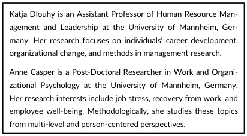

NOTE: figure/graphic rendered as an image from the PDF; its content is not machine-readable text. Caption (if any) follows as the next block.

**text found inside the figure**

Katja Dlouhy is an Assistant Professor of Human Resource Man-

agement and Leadership at the University of Mannheim, Ger-

many. Her research focuses on individuals' career development,

organizational change, and methods in management research.

Anne Casper is a Post-Doctoral Researcher in Work and Organi-

zational Psychology at the University of Mannheim, Germany.

Her research interests include job stress, recovery from work, and

employee well-being. Methodologically, she studies these topics

from multi-level and person-centered perspectives.

#### **SUPPORTING INFORMATION**

Additional supporting information may be found online in the

Supporting Information section at the end of this article.

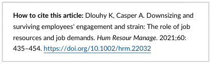

NOTE: figure/graphic rendered as an image from the PDF; its content is not machine-readable text. Caption (if any) follows as the next block.

**text found inside the figure**

**How to cite this article:** Dlouhy K, Casper A. Downsizing and

surviving employees' engagement and strain: The role of job

resources and job demands. *Hum Resour Manage*. 2021;60:

435–454. https://doi.org/10.1002/hrm.22032